# Seminar 3

Martin Søyland

# Disposisjon

1. Laste inn data #advanced
2. Omkoding #intermediate
3. Subsetting av data
4. OLS Samspill
5. Plotte predikerte effekter

# Laste inn data

Så langt i seminarene har vi gjort det veldig enkelt ved å laste inn data fra helt standard .csv-filer. Det finnes, dessverre, en haug med andre filtyper. La oss laste ned et datasett i mange forskjellige format fra http://folk.uio.no/martigso/stv4020/aiddata.zip

Her ligger data fra [Burnside & Dollar (2000)](http://www.jstor.org/stable/117311?seq=1#page_scan_tab_contents) i STATA- (.dta), SPSS- (.sav) og to versjoner av R-format (.rda / .RData). Pakk ut disse i mappen du vil jobbe fra, og la oss starte med det siste:

### R-data

```r
load("./data/aidgrowth/aidgrowth.rda")

head(aid, 3)
```

| country | period | gdp_growth | aid | policy | gdp_pr_capita | ethnic_frac | assasinations | sub_saharan_africa | fast_growing_east_asia | institutional_quality | m2_gdp_lagged |
| --- | --- | --- | --- | --- | --- | --- | --- | --- | --- | --- | --- |
| ARG | 2 | 1.700300 | 0.0182389 | 0.6565560 | 5637 | 0.31 | 2.75 | 0 | 0 | 4.28125 | 24.82476 |
| ARG | 3 | 1.077615 | 0.0171555 | -0.5792648 | 6168 | 0.31 | 9.75 | 0 | 0 | 4.28125 | 28.79304 |
| ARG | 4 | -1.115285 | 0.0239942 | -0.1356454 | 5849 | 0.31 | 1.00 | 0 | 0 | 4.28125 | 30.23452 |

```r
rm(aid) # rm() fjerner objektet fra Environment
```

### SPSS-data

```r
#install.packages("haven")

library(haven)

aid <- read_sav("./data/aidgrowth/aidgrowth.sav")
head(aid, 3)
```

| country | period | gdp_growth | aid | policy | gdp_pr_capita | ethnic_frac | assasinations | sub_saharan_africa | fast_growing_east_asia | institutional_quality | m2_gdp_lagged |
| --- | --- | --- | --- | --- | --- | --- | --- | --- | --- | --- | --- |
| ARG | 2 | 1.700300 | 0.0182389 | 0.6565560 | 5637 | 0.31 | 2.75 | 0 | 0 | 4.28125 | 24.82476 |
| ARG | 3 | 1.077615 | 0.0171555 | -0.5792648 | 6168 | 0.31 | 9.75 | 0 | 0 | 4.28125 | 28.79304 |
| ARG | 4 | -1.115285 | 0.0239942 | -0.1356454 | 5849 | 0.31 | 1.00 | 0 | 0 | 4.28125 | 30.23452 |

```r
rm(aid)
```

### STATA-data

```r
#install.packages("haven")
# library(haven)

aid <- read_dta("./data/aidgrowth/aidgrowth.dta")
head(aid, 3)
```

| country | period | gdp_growth | aid | policy | gdp_pr_capita | ethnic_frac | assasinations | sub_saharan_africa | fast_growing_east_asia | institutional_quality | m2_gdp_lagged |
| --- | --- | --- | --- | --- | --- | --- | --- | --- | --- | --- | --- |
| ARG | 2 | 1.700300 | 0.0182389 | 0.6565560 | 5637 | 0.31 | 2.75 | 0 | 0 | 4.28125 | 24.82476 |
| ARG | 3 | 1.077615 | 0.0171555 | -0.5792648 | 6168 | 0.31 | 9.75 | 0 | 0 | 4.28125 | 28.79304 |
| ARG | 4 | -1.115285 | 0.0239942 | -0.1356454 | 5849 | 0.31 | 1.00 | 0 | 0 | 4.28125 | 30.23452 |

# Kort introduksjon til subsetting av data

Noen ganger vil vi fjerne enheter fra datasettene våre. Det kan være vi kun vil se på trender innad i et land, sammenligne spesifikke grupper, fjerne enheter som skaper systematisk missing, og så videre. Under viser jeg to måter dette kan gjøres på – det finnes mange flere.

```r
# aid$country == "ARG"
# which(aid$country == "ARG")
# aid[which(aid$country == "ARG"), ]
argentina <- aid[which(aid$country == "ARG"), ]
argentina <- subset(aid, country == "ARG")

nomiss_policy <- aid[which(is.na(aid$policy) == FALSE), ]
nomiss_policy <- subset(aid, is.na(policy) == FALSE)

nomiss_policy_growth <- aid[which(is.na(aid$gdp_growth) == FALSE & is.na(aid$policy) == FALSE), ]
nomiss_policy_growth <- subset(aid, is.na(gdp_growth) == FALSE & is.na(policy) == FALSE)
```

# Replikasjon uten å gjøre noe

La oss kjapt kjøre alle variablene fra modell 5 i artikkelen inn i en regresjon og se om vi får samme resultat.

```r
model5 <- lm(gdp_growth ~ gdp_pr_capita + ethnic_frac * assasinations + institutional_quality +
               m2_gdp_lagged + sub_saharan_africa + fast_growing_east_asia + policy * aid,
             data = aid)
summary(model5)
```

```
Call:
lm(formula = gdp_growth ~ gdp_pr_capita + ethnic_frac * assasinations +
    institutional_quality + m2_gdp_lagged + sub_saharan_africa +
    fast_growing_east_asia + policy * aid, data = aid)

Residuals:
     Min       1Q   Median       3Q      Max
-12.1538  -1.5874   0.0386   1.5829  13.6089

Coefficients:
                            Estimate Std. Error t value Pr(>|t|)
(Intercept)               -1.0410219  0.9747372  -1.068  0.28652
gdp_pr_capita             -0.0003812  0.0001368  -2.786  0.00574 **
ethnic_frac               -0.4433386  0.8564135  -0.518  0.60513
assasinations             -0.4570900  0.3181723  -1.437  0.15204
institutional_quality      0.7537407  0.1858934   4.055 6.65e-05 ***
m2_gdp_lagged             -0.0137827  0.0162300  -0.849  0.39655
sub_saharan_africa        -1.9458082  0.7089091  -2.745  0.00648 **
fast_growing_east_asia     1.1109101  0.7742178   1.435  0.15253
policy                     0.7251472  0.2465391   2.941  0.00357 **
aid                       -0.1492503  0.1808464  -0.825  0.40997
ethnic_frac:assasinations  0.6781451  0.6604810   1.027  0.30550
policy:aid                 0.1563717  0.1064776   1.469  0.14316
---
Signif. codes:  0 '***' 0.001 '**' 0.01 '*' 0.05 '.' 0.1 ' ' 1

Residual standard error: 3.07 on 258 degrees of freedom
  (61 observations deleted due to missingness)
Multiple R-squared:  0.2947,    Adjusted R-squared:  0.2647
F-statistic: 9.802 on 11 and 258 DF,  p-value: 8.051e-15
```

Hvis vi sammenligner disse resultatene med resultatene i artikkelen ser vi kjapt at vi ikke har klart å replisere resultatene. Da må vi tilbake og lese teksten i artikkelen. Jeg har juksa og lest den på forhånd. Så jeg kan avsløre at det er noe som mangler her:

1. Gdp pr capita skal log-transformeres
2. De har kontrollert for periode, men ikke rapportert det
3. Område-dummiene er ikke satt til riktig målenivå
4. De viser ikke konstantledd; alltid vis konstantledd
5. (De bruker også “heteroskedasticity-consistent standard errors”)

# Omkoding

### Logging av variabler

I artikkelen blir gdp per capit log-transformert. Derfor må vi også gjøre det for å klare å replisere resultatene. Det er også lurt å ta vare på den gamle variabelen ved å gi den nye et nytt navn. Her `gdp_pr_capita_log`.

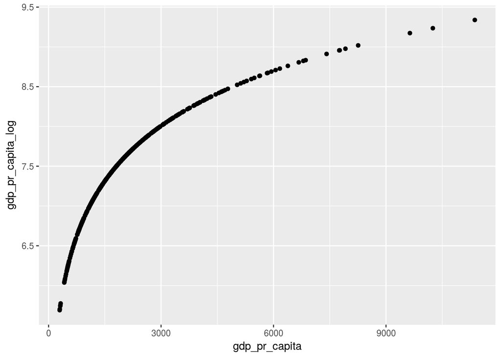

```r
aid$gdp_pr_capita_log <- log(aid$gdp_pr_capita)

library(ggplot2)

ggplot(aid, aes(x = gdp_pr_capita, y = gdp_pr_capita_log)) + geom_point()
```

Her ser vi veldig tydelig hva som skjer når vi logger en variabel; en økning på 1 er viktigere for lave tall enn for høye tall. Kort sagt betyr dette at vi mener det er viktigere å gå fra å være veldig fattig til litt mindre fattig, enn å gå fra å være veldig rik til enda rikere.

1. Gdp pr capita skal log-transformeres
2. De har kontrollert for periode, men ikke rapportert det
3. Område-dummiene er ikke satt til riktig målenivå
4. De viser ikke konstantledd; alltid vis konstantledd
5. (De bruker også “heteroskedasticity-consistent standard errors”)

### Omkode dummies til èn variabel

Mest for å vise litt forskjellige måter å kode på, fikser vi også dummysettet fra artikkelen inn i èn variabel. Dette kan gjøres på en million måter, men jeg skal vise to. Den første utnytter indeksering. Den andre bruker en snarvei, via funksjonen `ifelse()`.

```r
# Illustrasjon på which():
aid$country[which(aid$sub_saharan_africa == 0 & aid$fast_growing_east_asia == 1)]
which(aid$sub_saharan_africa == 0 & aid$fast_growing_east_asia == 1)
aid$sub_saharan_africa == 0 & aid$fast_growing_east_asia == 1
```

```r
aid$regions <- NA
aid$regions[which(aid$sub_saharan_africa == 0 & aid$fast_growing_east_asia == 0)] <- "Other"
aid$regions[which(aid$sub_saharan_africa == 1 & aid$fast_growing_east_asia == 0)] <- "Sub-Saharan Africa"
aid$regions[which(aid$sub_saharan_africa == 0 & aid$fast_growing_east_asia == 1)] <- "East Asia"
```

I den neste funksjonen bruker vi **nesting** med `ifelse()` for å gjøre akkurat det samme. Dette viser at de to variablene er helt identiske. Vi sjekker at det blir riktig, og setter kategorien “Other” til referansekategori med funksjonen `factor()`.

```r
# ?ifelse()

aid$regions2 <- ifelse(aid$sub_saharan_africa == 1, "Sub-Saharan Africa",
                       ifelse(aid$fast_growing_east_asia == 1, "East Asia", "Other"))

table(aid$regions, aid$regions2)
```

```
                     East Asia Other Sub-Saharan Africa
  East Asia                 30     0                  0
  Other                      0   177                  0
  Sub-Saharan Africa         0     0                124
```

```r
aid$regions <- factor(aid$regions, levels = c("Other", "Sub-Saharan Africa", "East Asia"))
```

1. Gdp pr capita skal log-transformeres
2. De har kontrollert for periode, men ikke rapportert det
3. Område-dummiene er ikke satt til riktig målenivå
4. De viser ikke konstantledd; alltid vis konstantledd
5. (De bruker også “heteroskedasticity-consistent standard errors”)

# Korrekt modell

Nå er vi faktisk klar til å kjøre regresjonen! Legg merke til at vi har satt inn `factor(period)` direkte i regresjonen

```r
model5 <- lm(gdp_growth ~ gdp_pr_capita_log + ethnic_frac * assasinations +
               institutional_quality + m2_gdp_lagged + regions + policy * aid +
               factor(period),
             data = aid, na.action = "na.exclude")
summary(model5)
```

```
Call:
lm(formula = gdp_growth ~ gdp_pr_capita_log + ethnic_frac * assasinations +
    institutional_quality + m2_gdp_lagged + regions + policy *
    aid + factor(period), data = aid, na.action = "na.exclude")

Residuals:
     Min       1Q   Median       3Q      Max
-10.7213  -1.6078  -0.1369   1.5895  12.0507

Coefficients:
                          Estimate Std. Error t value Pr(>|t|)
(Intercept)                3.39109    2.94549   1.151 0.250702
gdp_pr_capita_log         -0.59961    0.39262  -1.527 0.127965
ethnic_frac               -0.42359    0.81009  -0.523 0.601507
assasinations             -0.44895    0.30119  -1.491 0.137311
institutional_quality      0.68684    0.17452   3.936 0.000107 ***
m2_gdp_lagged              0.01222    0.01627   0.751 0.453130
regionsSub-Saharan Africa -1.87248    0.68095  -2.750 0.006393 **
regionsEast Asia           1.30739    0.73063   1.789 0.074747 .
policy                     0.71245    0.24359   2.925 0.003760 **
aid                       -0.02078    0.17808  -0.117 0.907182
factor(period)3           -0.01252    0.61994  -0.020 0.983901
factor(period)4           -1.41449    0.62920  -2.248 0.025434 *
factor(period)5           -3.46987    0.64085  -5.415 1.43e-07 ***
factor(period)6           -2.01030    0.66149  -3.039 0.002622 **
factor(period)7           -2.25625    0.70848  -3.185 0.001631 **
ethnic_frac:assasinations  0.79154    0.62031   1.276 0.203111
policy:aid                 0.18622    0.10113   1.841 0.066752 .
---
Signif. codes:  0 '***' 0.001 '**' 0.01 '*' 0.05 '.' 0.1 ' ' 1

Residual standard error: 2.873 on 253 degrees of freedom
  (61 observations deleted due to missingness)
Multiple R-squared:  0.3944,    Adjusted R-squared:  0.3561
F-statistic:  10.3 on 16 and 253 DF,  p-value: < 2.2e-16
```

```r
# "Heteroskedasticity-consistent standard errors"
library(sandwich)
cbind(round(coef(model5), digits = 2), round(sqrt(diag(vcovHC(model5, type = "HC"))), digits = 2))
```

```
                           [,1] [,2]
(Intercept)                3.39 4.11
gdp_pr_capita_log         -0.60 0.57
ethnic_frac               -0.42 0.72
assasinations             -0.45 0.26
institutional_quality      0.69 0.17
m2_gdp_lagged              0.01 0.01
regionsSub-Saharan Africa -1.87 0.75
regionsEast Asia           1.31 0.58
policy                     0.71 0.19
aid                       -0.02 0.16
factor(period)3           -0.01 0.57
factor(period)4           -1.41 0.63
factor(period)5           -3.47 0.59
factor(period)6           -2.01 0.53
factor(period)7           -2.26 0.64
ethnic_frac:assasinations  0.79 0.44
policy:aid                 0.19 0.07
```

1. Gdp pr capita skal log-transformeres
2. De har kontrollert for periode, men ikke rapportert det
3. Område-dummiene er ikke satt til riktig målenivå
4. De viser ikke konstantledd; alltid vis konstantledd
5. (De bruker også “heteroskedasticity-consistent standard errors”)

# Plot av forventede verdier (og restledd)

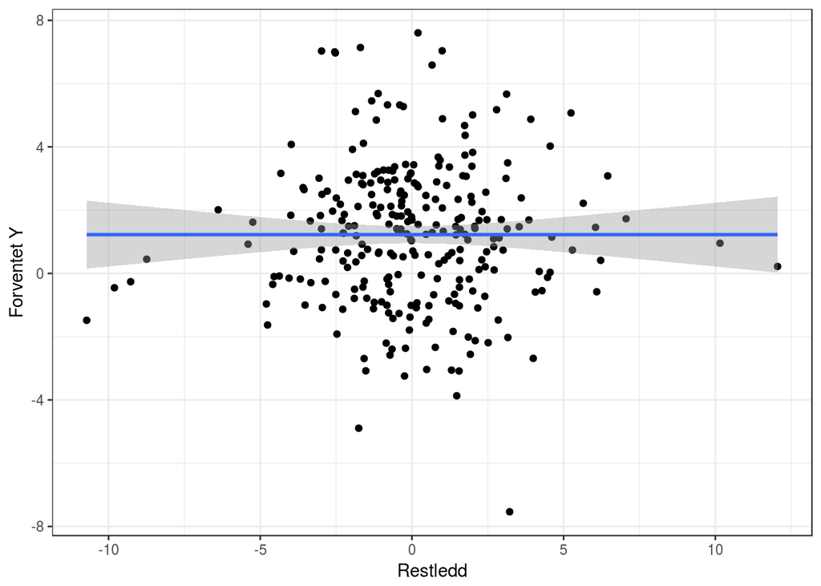

```r
theme_set(theme_bw())

aid$pred <- predict(model5)
aid$restledd <- resid(model5)

ggplot(aid, aes(x = restledd, y = pred)) + geom_point() +
  geom_smooth(method = "lm") +
  labs(x = "Restledd", y = "Forventet Y")
```

# Bonus!

Samspillsledd er vanskelige å tolke fra en regresjonstabell. Jeg foretrekker å plotte effektene. Her er et eksempel på hvordan dette kan gjøres. Det er mye som skjer her, så ha tunga rett i munnen når dere prøver dere på dette.

```r
snitt_data <- data.frame(gdp_pr_capita_log = mean(aid$gdp_pr_capita_log, na.rm = TRUE),
                         ethnic_frac = mean(aid$ethnic_frac, na.rm = TRUE),
                         assasinations = mean(aid$assasinations, na.rm = TRUE),
                         institutional_quality = mean(aid$institutional_quality, na.rm = TRUE),
                         m2_gdp_lagged = mean(aid$m2_gdp_lagged, na.rm = TRUE),
                         regions = "Other",
                         policy = c(0, 1),
                         aid = rep(0:8, 2),
                         period = median(aid$period, na.rm = TRUE))

predict(model5, newdata = snitt_data, se = TRUE)
```

```
$fit
        1         2         3         4         5         6         7
0.7965482 1.6744313 0.7549809 2.0052960 0.7134137 2.3361608 0.6718465
        8         9        10        11        12        13        14
2.6670256 0.6302793 1.5089989 0.7757645 1.8398636 0.7341973 2.1707284
       15        16        17        18
0.6926301 2.5015932 0.6510629 2.8324579

$se.fit
        1         2         3         4         5         6         7
0.5782802 0.4898167 0.5362879 0.5629815 0.7032047 0.7572607 0.9772843
        8         9        10        11        12        13        14
1.0046925 1.2920401 0.5183695 0.5284831 0.5059652 0.5994488 0.6502018
       15        16        17        18
0.8325135 0.8769218 1.1315980 1.1378441

$df
[1] 253

$residual.scale
[1] 2.872583
```

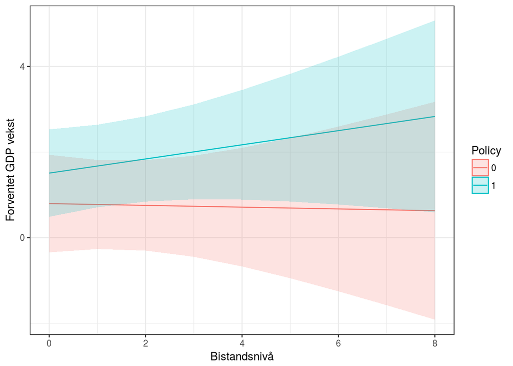

```r
snitt_data <- cbind(snitt_data, predict(model5, newdata = snitt_data,
                                        se = TRUE, interval = "confidence"))

ggplot(snitt_data, aes(x = aid, y = fit.fit,
                       group = factor(policy),
                       color = factor(policy),
                       fill = factor(policy))) +
  geom_line() +
  scale_y_continuous(breaks = seq(-12, 12, 4)) +
  geom_ribbon(aes(ymin = fit.lwr, ymax = fit.upr, color = NULL), alpha = .2) +
  labs(x = "Bistandsnivå", y = "Forventet GDP vekst", color = "Policy", fill = "Policy")
```